# Homework 2 - Problem 3: Linear Regression

```r
youtube <- read.csv(
  "https://raw.githubusercontent.com/rfordatascience/tidytuesday/master/data/2021/2021-03-02/youtube.csv"
)

characteristics <- c(
  "funny", "show_product_quickly", "patriotic", "celebrity",
  "danger", "animals", "use_sex"
)

engagement <- c(
  "view_count", "like_count", "dislike_count",
  "favorite_count", "comment_count"
)
```

## (a) Data preparation and de-identification

I removed the brand and all fields that identify a video or describe its YouTube publication. These fields are the two URLs, YouTube ID, kind, etag, publication time, title, description, thumbnail, channel name, and category ID. The remaining data contain only year, the seven binary characteristics, and the five engagement variables.

```r
identifying_variables <- c(
  "brand", "superbowl_ads_dot_com_url", "youtube_url", "id", "kind",
  "etag", "published_at", "title", "description", "thumbnail",
  "channel_title", "category_id"
)

youtube_deidentified <- youtube[
  setdiff(names(youtube), identifying_variables)
]

dim(youtube_deidentified)
```

```
[1] 247  13
```

The de-identified data set has 247 rows and 13 columns.

## (b) Exploring potential outcomes

The table below summarizes the distributions. The maximum values are much larger than the medians for all four nonconstant engagement counts, indicating strong right skew. Because some of these variables contain zeros, I use `log1p(x)`, which is equal to `log(1 + x)`, rather than `log(x)`.

```r
distribution_summary <- do.call(
  rbind,
  lapply(engagement, function(variable) {
    x <- youtube_deidentified[[variable]]
    data.frame(
      variable = variable,
      non_missing = sum(!is.na(x)),
      missing = sum(is.na(x)),
      zeros = sum(x == 0, na.rm = TRUE),
      minimum = min(x, na.rm = TRUE),
      median = median(x, na.rm = TRUE),
      mean = mean(x, na.rm = TRUE),
      maximum = max(x, na.rm = TRUE)
    )
  })
)

knitr::kable(distribution_summary, digits = 1)
```

| variable | non_missing | missing | zeros | minimum | median | mean | maximum |
| --- | --- | --- | --- | --- | --- | --- | --- |
| view_count | 231 | 16 | 0 | 10 | 41379 | 1407556.5 | 176373378 |
| like_count | 225 | 22 | 9 | 0 | 130 | 4146.0 | 275362 |
| dislike_count | 225 | 22 | 47 | 0 | 7 | 833.5 | 92990 |
| favorite_count | 231 | 16 | 231 | 0 | 0 | 0.0 | 0 |
| comment_count | 222 | 25 | 41 | 0 | 10 | 188.6 | 9190 |

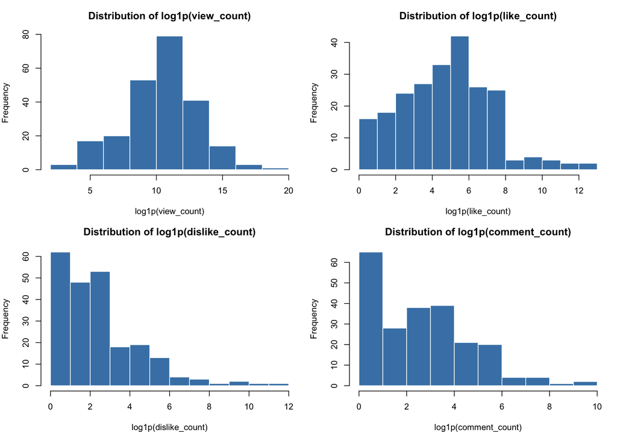

```r
par(mfrow = c(2, 2), mar = c(4, 4, 3, 1))
for (variable in setdiff(engagement, "favorite_count")) {
  hist(
    log1p(youtube_deidentified[[variable]]),
    main = paste("Distribution of log1p(", variable, ")", sep = ""),
    xlab = paste0("log1p(", variable, ")"),
    col = "steelblue",
    border = "white"
  )
}
```

```r
par(mfrow = c(1, 1))
```

My decisions are:

- `view_count`: category 2. It is extremely right-skewed, so I use `log1p(view_count)`.
- `like_count`: category 2. It is right-skewed and contains zeros, so I use `log1p(like_count)`.
- `dislike_count`: category 2. It is right-skewed and contains zeros, so I use `log1p(dislike_count)`.
- `favorite_count`: category 3. Every one of its 231 observed values is zero, so it has no variation for a linear regression to explain.
- `comment_count`: category 2. It is right-skewed and contains zeros, so I use `log1p(comment_count)`.

```r
analysis_data <- youtube_deidentified
analysis_data[characteristics] <- lapply(
  analysis_data[characteristics], as.integer
)

analysis_data$log_view_count <- log1p(analysis_data$view_count)
analysis_data$log_like_count <- log1p(analysis_data$like_count)
analysis_data$log_dislike_count <- log1p(analysis_data$dislike_count)
analysis_data$log_comment_count <- log1p(analysis_data$comment_count)
```

## (c) Fitting linear regression models

For every outcome-characteristic combination, I fit a separate model of the form `transformed outcome ~ binary characteristic + year`. The coefficient reported below is for the binary characteristic and is adjusted for year.

```r
outcomes <- c(
  "log_view_count", "log_like_count",
  "log_dislike_count", "log_comment_count"
)

model_results <- do.call(
  rbind,
  lapply(outcomes, function(outcome) {
    do.call(
      rbind,
      lapply(characteristics, function(characteristic) {
        model <- lm(
          reformulate(c(characteristic, "year"), response = outcome),
          data = analysis_data
        )
        coefficient <- coef(summary(model))[characteristic, ]
        data.frame(
          outcome = outcome,
          characteristic = characteristic,
          estimate = unname(coefficient["Estimate"]),
          p_value = unname(coefficient["Pr(>|t|)"])
        )
      })
    )
  })
)

display_results <- model_results
display_results$estimate <- round(display_results$estimate, 4)
display_results$p_value <- format.pval(
  display_results$p_value, digits = 4, eps = 0.0001
)
knitr::kable(display_results)
```

| outcome | characteristic | estimate | p_value |
| --- | --- | --- | --- |
| log_view_count | funny | 0.5298 | 0.20511 |
| log_view_count | show_product_quickly | 0.2090 | 0.60072 |
| log_view_count | patriotic | 0.1369 | 0.78392 |
| log_view_count | celebrity | -0.0190 | 0.96289 |
| log_view_count | danger | 0.6668 | 0.09406 |
| log_view_count | animals | -0.1733 | 0.64669 |
| log_view_count | use_sex | -0.2963 | 0.49052 |
| log_like_count | funny | 0.3602 | 0.34006 |
| log_like_count | show_product_quickly | 0.1683 | 0.64048 |
| log_like_count | patriotic | 0.4931 | 0.28968 |
| log_like_count | celebrity | 0.2630 | 0.47788 |
| log_like_count | danger | 0.6253 | 0.08032 |
| log_like_count | animals | 0.0246 | 0.94283 |
| log_like_count | use_sex | -0.3250 | 0.40009 |
| log_dislike_count | funny | 0.0415 | 0.89581 |
| log_dislike_count | show_product_quickly | 0.2429 | 0.42097 |
| log_dislike_count | patriotic | 0.6697 | 0.08564 |
| log_dislike_count | celebrity | -0.2833 | 0.36163 |
| log_dislike_count | danger | 0.1851 | 0.53795 |
| log_dislike_count | animals | -0.0738 | 0.79742 |
| log_dislike_count | use_sex | -0.3889 | 0.22928 |
| log_comment_count | funny | 0.0475 | 0.87935 |
| log_comment_count | show_product_quickly | 0.3460 | 0.24686 |
| log_comment_count | patriotic | 0.5148 | 0.16854 |
| log_comment_count | celebrity | 0.2281 | 0.45559 |
| log_comment_count | danger | 0.1064 | 0.72096 |
| log_comment_count | animals | -0.1918 | 0.49907 |
| log_comment_count | use_sex | -0.3494 | 0.27354 |

The assignment text does not display a numerical significance level, so I use the conventional alpha = 0.05. At this level, none of the seven commercial characteristics has a statistically significant association with any of the four analyzed engagement outcomes after adjusting for year. Therefore, there are no statistically significant positive or negative associations to report.

For view counts, `danger` has the largest positive estimated association: its estimated coefficient is 0.6668 on the `log1p(view_count)` scale. It also has the smallest view-count p-value (0.0941).

## (d) Estimating regression coefficients using matrix algebra

Among the seven view-count models, `danger` has the smallest p-value. I therefore fit `log1p(view_count) ~ danger + year`. After removing rows with missing values, the design matrix contains a column of ones for the intercept, followed by `danger` and `year`. I calculate the coefficient vector with the ordinary least-squares formula beta-hat = (X-transpose X)^(-1) X-transpose y, without using `lm()`.

```r
matrix_data <- analysis_data[
  complete.cases(
    analysis_data[c("log_view_count", "danger", "year")]
  ),
  c("log_view_count", "danger", "year")
]

X <- cbind(
  `(Intercept)` = 1,
  danger = matrix_data$danger,
  year = matrix_data$year
)
y <- matrix_data$log_view_count

beta_matrix <- solve(t(X) %*% X) %*% t(X) %*% y
beta_matrix
```

```
                    [,1]
(Intercept) -31.39149243
danger        0.66678076
year          0.02065641
```

For comparison, I fit exactly the same model using `lm()`.

```r
comparison_model <- lm(
  log_view_count ~ danger + year,
  data = matrix_data
)

comparison <- data.frame(
  term = names(coef(comparison_model)),
  matrix_algebra = as.numeric(beta_matrix),
  lm = as.numeric(coef(comparison_model)),
  absolute_difference = abs(
    as.numeric(beta_matrix) - as.numeric(coef(comparison_model))
  )
)

knitr::kable(comparison, digits = 12)
```

| term | matrix_algebra | lm | absolute_difference |
| --- | --- | --- | --- |
| (Intercept) | -31.39149243 | -31.39149243 | 3.34e-10 |
| danger | 0.66678076 | 0.66678076 | 0.00e+00 |
| year | 0.02065641 | 0.02065641 | 0.00e+00 |

```r
all.equal(
  as.numeric(beta_matrix),
  as.numeric(coef(comparison_model)),
  tolerance = 1e-10
)
```

```
[1] TRUE
```

The absolute differences are only numerical rounding error, and `all.equal()` returns `TRUE`. Thus, the matrix calculation and `lm()` produce the same estimated coefficients up to numerical precision.